# PROMOTION ABONNEMENT ANNUEL DES VELOS LIBRE SERVICES

Minosoa Rasolonjatovo

2025

```r
setwd("C:/Users/minos/OneDrive/Documents/2025/portfolio1")
getwd
```

```
## function ()
## .Internal(getwd())
## <bytecode: 0x000001b00084ad98>
## <environment: namespace:base>
```

#CONSTITUTION DE LA BASE DE DONNEES

```r
library (readr)
q1_2019 <- read.csv("Divvy_Trips_2019_Q1.csv")
q1_2020 <- read.csv("Divvy_Trips_2020_Q1.csv")
```

Les bases de données concernent des enregistrements de trajets réalisés sur un trimestre des années 2019 et 2020. les données proviennent de la base de données de l’entreprise auprès des bornes à vélos dispersés un peu partout dans la ville de Chicago

```r
col_data_2019 <- colnames(q1_2019)
col_data_2020 <- colnames(q1_2020)
```

Les noms des variables sont différentes dans les deux bases de données. Nénamoins, on y retrouve des informations communes. Nous allons renommer certaines variable de l’année 2019, de sorte à rassembler les informations similaires

```r
#renommer les colonnes
library(dplyr)
q1_2019 <- rename(q1_2019
                     ,ride_id = trip_id
                   ,rideable_type = bikeid
                   ,started_at = start_time
                   ,ended_at = end_time
                   ,start_station_name = from_station_name
                   ,start_station_id = from_station_id
                   ,end_station_name = to_station_name
                   ,end_station_id = to_station_id
                   ,member_casual = usertype
                   )
str(q1_2019)
```

```
## 'data.frame':    365069 obs. of  12 variables:
##  $ ride_id           : int  21742443 21742444 21742445 21742446 21742447 21742448 21742449 21742450 21742451 21742452 ...
##  $ started_at        : chr  "2019-01-01 0:04:37" "2019-01-01 0:08:13" "2019-01-01 0:13:23" "2019-01-01 0:13:45" ...
##  $ ended_at          : chr  "2019-01-01 0:11:07" "2019-01-01 0:15:34" "2019-01-01 0:27:12" "2019-01-01 0:43:28" ...
##  $ rideable_type     : int  2167 4386 1524 252 1170 2437 2708 2796 6205 3939 ...
##  $ tripduration      : chr  "390" "441" "829" "1,783.00" ...
##  $ start_station_id  : int  199 44 15 123 173 98 98 211 150 268 ...
##  $ start_station_name: chr  "Wabash Ave & Grand Ave" "State St & Randolph St" "Racine Ave & 18th St" "California Ave & Milwaukee Ave" ...
##  $ end_station_id    : int  84 624 644 176 35 49 49 142 148 141 ...
##  $ end_station_name  : chr  "Milwaukee Ave & Grand Ave" "Dearborn St & Van Buren St (*)" "Western Ave & Fillmore St (*)" "Clark St & Elm St" ...
##  $ member_casual     : chr  "Subscriber" "Subscriber" "Subscriber" "Subscriber" ...
##  $ gender            : chr  "Male" "Female" "Female" "Male" ...
##  $ birthyear         : int  1989 1990 1994 1993 1994 1983 1984 1990 1995 1996 ...
```

```r
str(q1_2020)
```

```
## 'data.frame':    426887 obs. of  13 variables:
##  $ ride_id           : chr  "EACB19130B0CDA4A" "8FED874C809DC021" "789F3C21E472CA96" "C9A388DAC6ABF313" ...
##  $ rideable_type     : chr  "docked_bike" "docked_bike" "docked_bike" "docked_bike" ...
##  $ started_at        : chr  "2020-01-21 20:06:59" "2020-01-30 14:22:39" "2020-01-09 19:29:26" "2020-01-06 16:17:07" ...
##  $ ended_at          : chr  "2020-01-21 20:14:30" "2020-01-30 14:26:22" "2020-01-09 19:32:17" "2020-01-06 16:25:56" ...
##  $ start_station_name: chr  "Western Ave & Leland Ave" "Clark St & Montrose Ave" "Broadway & Belmont Ave" "Clark St & Randolph St" ...
##  $ start_station_id  : int  239 234 296 51 66 212 96 96 212 38 ...
##  $ end_station_name  : chr  "Clark St & Leland Ave" "Southport Ave & Irving Park Rd" "Wilton Ave & Belmont Ave" "Fairbanks Ct & Grand Ave" ...
##  $ end_station_id    : int  326 318 117 24 212 96 212 212 96 100 ...
##  $ start_lat         : num  42 42 41.9 41.9 41.9 ...
##  $ start_lng         : num  -87.7 -87.7 -87.6 -87.6 -87.6 ...
##  $ end_lat           : num  42 42 41.9 41.9 41.9 ...
##  $ end_lng           : num  -87.7 -87.7 -87.7 -87.6 -87.6 ...
##  $ member_casual     : chr  "member" "member" "member" "member" ...
```

```r
#remplacer le type des éléments contenus dans ride_id et rideable_id dans la database 2019
q1_2019 <- mutate(q1_2019, ride_id=as.character(ride_id)
                    ,rideable_type=as.character(rideable_type))
```

Afin de constituer la base de données 2019 début 2020, nous allons préparer les bases de données des second, 3ème et 4ème trimestre de l’année 2019.

```r
#Trimetre 2
q2_2019 <- read.csv("Divvy_Trips_2019_Q2.csv")
str(q2_2019)
```

```
## 'data.frame':    1108163 obs. of  12 variables:
##  $ X01...Rental.Details.Rental.ID                   : int  22178529 22178530 22178531 22178532 22178533 22178534 22178535 22178536 22178537 22178538 ...
##  $ X01...Rental.Details.Local.Start.Time            : chr  "2019-04-01 00:02:22" "2019-04-01 00:03:02" "2019-04-01 00:11:07" "2019-04-01 00:13:01" ...
##  $ X01...Rental.Details.Local.End.Time              : chr  "2019-04-01 00:09:48" "2019-04-01 00:20:30" "2019-04-01 00:15:19" "2019-04-01 00:18:58" ...
##  $ X01...Rental.Details.Bike.ID                     : int  6251 6226 5649 4151 3270 3123 6418 4513 3280 5534 ...
##  $ X01...Rental.Details.Duration.In.Seconds.Uncapped: chr  "446.0" "1,048.0" "252.0" "357.0" ...
##  $ X03...Rental.Start.Station.ID                    : int  81 317 283 26 202 420 503 260 211 211 ...
##  $ X03...Rental.Start.Station.Name                  : chr  "Daley Center Plaza" "Wood St & Taylor St" "LaSalle St & Jackson Blvd" "McClurg Ct & Illinois St" ...
##  $ X02...Rental.End.Station.ID                      : int  56 59 174 133 129 426 500 499 211 211 ...
##  $ X02...Rental.End.Station.Name                    : chr  "Desplaines St & Kinzie St" "Wabash Ave & Roosevelt Rd" "Canal St & Madison St" "Kingsbury St & Kinzie St" ...
##  $ User.Type                                        : chr  "Subscriber" "Subscriber" "Subscriber" "Subscriber" ...
##  $ Member.Gender                                    : chr  "Male" "Female" "Male" "Male" ...
##  $ X05...Member.Details.Member.Birthday.Year        : int  1975 1984 1990 1993 1992 1999 1969 1991 NA NA ...
```

```r
colnames(q2_2019)
```

```
##  [1] "X01...Rental.Details.Rental.ID"
##  [2] "X01...Rental.Details.Local.Start.Time"
##  [3] "X01...Rental.Details.Local.End.Time"
##  [4] "X01...Rental.Details.Bike.ID"
##  [5] "X01...Rental.Details.Duration.In.Seconds.Uncapped"
##  [6] "X03...Rental.Start.Station.ID"
##  [7] "X03...Rental.Start.Station.Name"
##  [8] "X02...Rental.End.Station.ID"
##  [9] "X02...Rental.End.Station.Name"
## [10] "User.Type"
## [11] "Member.Gender"
## [12] "X05...Member.Details.Member.Birthday.Year"
```

```r
#remplacer les noms et types des variables pour permettre la fusion
q2_2019 <- rename(q2_2019
                  ,ride_id = X01...Rental.Details.Rental.ID
                  ,rideable_type = X01...Rental.Details.Bike.ID
                   ,started_at = X01...Rental.Details.Local.Start.Time
                   ,ended_at = X01...Rental.Details.Local.End.Time
                   ,start_station_name = X03...Rental.Start.Station.Name
                   ,start_station_id = X03...Rental.Start.Station.ID
                   ,end_station_name = X02...Rental.End.Station.Name
                   ,end_station_id = X02...Rental.End.Station.ID
                   ,member_casual = User.Type
                  )
q2_2019 <- mutate(q2_2019
                  , ride_id=as.character(ride_id)
                  , rideable_type=as.character(rideable_type)
                  )

#Trimestre 3
q3_2019 <- read.csv("Divvy_Trips_2019_Q3.csv")
str(q3_2019)
```

```
## 'data.frame':    1640718 obs. of  12 variables:
##  $ trip_id          : int  23479388 23479389 23479390 23479391 23479392 23479393 23479394 23479395 23479396 23479397 ...
##  $ start_time       : chr  "2019-07-01 00:00:27" "2019-07-01 00:01:16" "2019-07-01 00:01:48" "2019-07-01 00:02:07" ...
##  $ end_time         : chr  "2019-07-01 00:20:41" "2019-07-01 00:18:44" "2019-07-01 00:27:42" "2019-07-01 00:27:10" ...
##  $ bikeid           : int  3591 5353 6180 5540 6014 4941 3770 5442 2957 6091 ...
##  $ tripduration     : chr  "1,214.0" "1,048.0" "1,554.0" "1,503.0" ...
##  $ from_station_id  : int  117 381 313 313 168 300 168 313 43 43 ...
##  $ from_station_name: chr  "Wilton Ave & Belmont Ave" "Western Ave & Monroe St" "Lakeview Ave & Fullerton Pkwy" "Lakeview Ave & Fullerton Pkwy" ...
##  $ to_station_id    : int  497 203 144 144 62 232 62 144 195 195 ...
##  $ to_station_name  : chr  "Kimball Ave & Belmont Ave" "Western Ave & 21st St" "Larrabee St & Webster Ave" "Larrabee St & Webster Ave" ...
##  $ usertype         : chr  "Subscriber" "Customer" "Customer" "Customer" ...
##  $ gender           : chr  "Male" "" "" "" ...
##  $ birthyear        : int  1992 NA NA NA NA 1990 NA NA NA NA ...
```

```r
q3_2019 <- rename(q3_2019
                  ,ride_id = trip_id
                  ,rideable_type = bikeid
                   ,started_at = start_time
                   ,ended_at = end_time
                   ,start_station_name = from_station_name
                   ,start_station_id = from_station_id
                   ,end_station_name = to_station_name
                   ,end_station_id = to_station_id
                   ,member_casual = usertype
                  )
q3_2019 <- mutate(q3_2019
                  , ride_id=as.character(ride_id)
                  , rideable_type=as.character(rideable_type)
                  )

#Trimestre 4
q4_2019 <- read.csv("Divvy_Trips_2019_Q4.csv")
str(q4_2019)
```

```
## 'data.frame':    704054 obs. of  12 variables:
##  $ trip_id          : int  25223640 25223641 25223642 25223643 25223644 25223645 25223646 25223647 25223648 25223649 ...
##  $ start_time       : chr  "2019-10-01 00:01:39" "2019-10-01 00:02:16" "2019-10-01 00:04:32" "2019-10-01 00:04:32" ...
##  $ end_time         : chr  "2019-10-01 00:17:20" "2019-10-01 00:06:34" "2019-10-01 00:18:43" "2019-10-01 00:43:43" ...
##  $ bikeid           : int  2215 6328 3003 3275 5294 1891 1061 1274 6011 2957 ...
##  $ tripduration     : chr  "940.0" "258.0" "850.0" "2,350.0" ...
##  $ from_station_id  : int  20 19 84 313 210 156 84 156 156 336 ...
##  $ from_station_name: chr  "Sheffield Ave & Kingsbury St" "Throop (Loomis) St & Taylor St" "Milwaukee Ave & Grand Ave" "Lakeview Ave & Fullerton Pkwy" ...
##  $ to_station_id    : int  309 241 199 290 382 226 142 463 463 336 ...
##  $ to_station_name  : chr  "Leavitt St & Armitage Ave" "Morgan St & Polk St" "Wabash Ave & Grand Ave" "Kedzie Ave & Palmer Ct" ...
##  $ usertype         : chr  "Subscriber" "Subscriber" "Subscriber" "Subscriber" ...
##  $ gender           : chr  "Male" "Male" "Female" "Male" ...
##  $ birthyear        : int  1987 1998 1991 1990 1987 1994 1991 1995 1993 NA ...
```

```r
q4_2019 <- rename(q4_2019
                  ,ride_id = trip_id
                  ,rideable_type = bikeid
                   ,started_at = start_time
                   ,ended_at = end_time
                   ,start_station_name = from_station_name
                   ,start_station_id = from_station_id
                   ,end_station_name = to_station_name
                   ,end_station_id = to_station_id
                   ,member_casual = usertype
                  )
q4_2019 <- mutate(q4_2019
                  , ride_id=as.character(ride_id)
                  , rideable_type=as.character(rideable_type)
                  )
```

Nous étudierons donc l’utilisation des vélos libre-service de l’année 2019 entière jusqu’à la fin du 1er trimestre 2020.

```r
all_trips <- bind_rows(q1_2019, q2_2019, q3_2019, q4_2019, q1_2020)
colnames(all_trips)
```

```
##  [1] "ride_id"
##  [2] "started_at"
##  [3] "ended_at"
##  [4] "rideable_type"
##  [5] "tripduration"
##  [6] "start_station_id"
##  [7] "start_station_name"
##  [8] "end_station_id"
##  [9] "end_station_name"
## [10] "member_casual"
## [11] "gender"
## [12] "birthyear"
## [13] "X01...Rental.Details.Duration.In.Seconds.Uncapped"
## [14] "Member.Gender"
## [15] "X05...Member.Details.Member.Birthday.Year"
## [16] "start_lat"
## [17] "start_lng"
## [18] "end_lat"
## [19] "end_lng"
```

```r
col_data_2020
```

```
##  [1] "ride_id"            "rideable_type"      "started_at"
##  [4] "ended_at"           "start_station_name" "start_station_id"
##  [7] "end_station_name"   "end_station_id"     "start_lat"
## [10] "start_lng"          "end_lat"            "end_lng"
## [13] "member_casual"
```

```r
col_data_2019
```

```
##  [1] "trip_id"           "start_time"        "end_time"
##  [4] "bikeid"            "tripduration"      "from_station_id"
##  [7] "from_station_name" "to_station_id"     "to_station_name"
## [10] "usertype"          "gender"            "birthyear"
```

En comparant les noms des colonnes des 3 dataframes, nous pouvons voir que l’année 2020 ne dispose pas de valeurs pour les variables : * tripduration * gender *birthyear et l’année 2019 des valeurs pour les variables :* start_lat * start_lng * end_lat * end_lng Nous allons donc enlever ces variables de notre base de données afin de résoudre le problème de données manquantes.

#NETTOYGE DE BASE DE DONNEES POUR ANALYSE

```r
all_trips <- all_trips %>% select(-c("start_lat", "start_lng", "end_lat", "end_lng", "tripduration", "gender", "birthyear", "X01...Rental.Details.Duration.In.Seconds.Uncapped", "X05...Member.Details.Member.Birthday.Year", "Member.Gender" ))
colnames(all_trips)
```

```
## [1] "ride_id"            "started_at"         "ended_at"
## [4] "rideable_type"      "start_station_id"   "start_station_name"
## [7] "end_station_id"     "end_station_name"   "member_casual"
```

#EXPLORATION BASE DE DONNEES

```r
colnames(all_trips)  #List of column names
```

```
## [1] "ride_id"            "started_at"         "ended_at"
## [4] "rideable_type"      "start_station_id"   "start_station_name"
## [7] "end_station_id"     "end_station_name"   "member_casual"
```

```r
nrow(all_trips)  #How many rows are in data frame?
```

```
## [1] 4244891
```

```r
dim(all_trips)  #Dimensions of the data frame?
```

```
## [1] 4244891       9
```

```r
str(all_trips)  #See list of columns and data types (numeric, character, etc)
```

```
## 'data.frame':    4244891 obs. of  9 variables:
##  $ ride_id           : chr  "21742443" "21742444" "21742445" "21742446" ...
##  $ started_at        : chr  "2019-01-01 0:04:37" "2019-01-01 0:08:13" "2019-01-01 0:13:23" "2019-01-01 0:13:45" ...
##  $ ended_at          : chr  "2019-01-01 0:11:07" "2019-01-01 0:15:34" "2019-01-01 0:27:12" "2019-01-01 0:43:28" ...
##  $ rideable_type     : chr  "2167" "4386" "1524" "252" ...
##  $ start_station_id  : int  199 44 15 123 173 98 98 211 150 268 ...
##  $ start_station_name: chr  "Wabash Ave & Grand Ave" "State St & Randolph St" "Racine Ave & 18th St" "California Ave & Milwaukee Ave" ...
##  $ end_station_id    : int  84 624 644 176 35 49 49 142 148 141 ...
##  $ end_station_name  : chr  "Milwaukee Ave & Grand Ave" "Dearborn St & Van Buren St (*)" "Western Ave & Fillmore St (*)" "Clark St & Elm St" ...
##  $ member_casual     : chr  "Subscriber" "Subscriber" "Subscriber" "Subscriber" ...
```

```r
head(all_trips)
```

```
##    ride_id         started_at           ended_at rideable_type start_station_id
## 1 21742443 2019-01-01 0:04:37 2019-01-01 0:11:07          2167              199
## 2 21742444 2019-01-01 0:08:13 2019-01-01 0:15:34          4386               44
## 3 21742445 2019-01-01 0:13:23 2019-01-01 0:27:12          1524               15
## 4 21742446 2019-01-01 0:13:45 2019-01-01 0:43:28           252              123
## 5 21742447 2019-01-01 0:14:52 2019-01-01 0:20:56          1170              173
## 6 21742448 2019-01-01 0:15:33 2019-01-01 0:19:09          2437               98
##                    start_station_name end_station_id
## 1              Wabash Ave & Grand Ave             84
## 2              State St & Randolph St            624
## 3                Racine Ave & 18th St            644
## 4      California Ave & Milwaukee Ave            176
## 5 Mies van der Rohe Way & Chicago Ave             35
## 6          LaSalle St & Washington St             49
##                 end_station_name member_casual
## 1      Milwaukee Ave & Grand Ave    Subscriber
## 2 Dearborn St & Van Buren St (*)    Subscriber
## 3  Western Ave & Fillmore St (*)    Subscriber
## 4              Clark St & Elm St    Subscriber
## 5        Streeter Dr & Grand Ave    Subscriber
## 6        Dearborn St & Monroe St    Subscriber
```

```r
#Identification des valeurs manquantes
colSums(is.na(all_trips)) #nombre de Valeurs manquantes par variable
```

```
##            ride_id         started_at           ended_at      rideable_type
##                  0                  0                  0                  0
##   start_station_id start_station_name     end_station_id   end_station_name
##                  0                  0                  1                  0
##      member_casual
##                  0
```

```r
#member_casual
unique(all_trips$member_casual) # les valeurs de la variable catégorielle
```

```
## [1] "Subscriber" "Customer"   "member"     "casual"
```

```r
table(all_trips$member_casual)
```

```
##
##     casual   Customer     member Subscriber
##      48480     880637     378407    2937367
```

***Les utilisateurs : abonnés et non-abonnés On remarque qu’il y a 4 catégories d’utilisateurs alors qu’on en distingue que deux : les abonnés : “member” et “Subscriber” les utilisateurs occasionnels : “Customer” et “casual” On va donc remplacer “Subscriber” par “member”, puis “Customer” par “casual” pour n’avoir que deux valeurs uniques:* “member”: pour les utilisateurs avec un abonnement annuel * “casual”: pour les utilisateurs ponctuels sans abonnement

```r
all_trips <- all_trips %>% mutate(member_casual= recode(member_casual,
                                                        "Subscriber"="member",
                                                        "Customer"="casual"))
table(all_trips$member_casual)
```

```
##
##  casual  member
##  929117 3315774
```

***Les dates Nous allons travailler sur la variable “started_at”, afin d’obtenir les éléments suivants : - l’année : “year” - le mois : “month” - le jour du trajet: “day_of_week” - la durée d’un trajet : “ride_length”, en secondes, qui sera calculer en soustrayant l’heure de “ended_at” à l’heure de “started_at”.

```r
all_trips$date <- as.Date(all_trips$started_at) #The default format is yyyy-mm-dd
all_trips$month <- format(as.Date(all_trips$date), "%B") # %B :Pour avoir les mois en toute lettre
all_trips$day <- format(as.Date(all_trips$date), "%d")
all_trips$year <- format(as.Date(all_trips$date), "%Y")
all_trips$day_of_week <- format(as.Date(all_trips$date), "%A") # Pour avoir le jour de la semaine

# Add a "ride_length" calculation to all_trips (in seconds)
all_trips$ride_length <- difftime(all_trips$ended_at,all_trips$started_at) #on a un nouveau variable de type difftime

all_trips$ride_length <- as.numeric(all_trips$ride_length)
is.numeric(all_trips$ride_length)
```

```
## [1] TRUE
```

```r
#Variable "ride_length", type numérique
```

#CREATION BASE DE DONNEES FINALE Certains trajets qui ont été répertoriés sont en réalité des entrées lorsque les vélos ont été sortis des docks et pour un contrôle de qualité par Divvy. Nous allons donc enlever ces entrées en créant une deuxième version de cette base de données sans ces entrées.

```r
all_trips_v2 <- all_trips[!(all_trips$start_station_name == "HQ QR" | all_trips$ride_length<0),]
sum(duplicated(all_trips_v2))
```

```
## [1] 0
```

Nous avons, de ce fait, finalisé la création de la base de données qui sera utilisée pour notre analyse. Pour rappel, l’objectif est de connaître *de quelles manières l’usage des vélos des utilisateurs avec abonnement annuel et des utilisateurs ponctuels diffèrent.*

##Analyse Descriptive des données ### Durée du trajet (ride_length) et groupes d’utilisateurs (member_casual)

```r
#ride_length
summary(all_trips_v2$ride_length)
```

```
##     Min.  1st Qu.   Median     Mean  3rd Qu.     Max.
##        0        0        0      629        0 10623600
```

```r
#member_casual

table1 <- all_trips_v2 %>% group_by(member_casual) %>%
  add_count(member_casual, name = "number") %>%
  summarise(
    max = max(ride_length),
    mean = mean(ride_length),
    median = median(ride_length),
    min = min(ride_length),
    category_count = first(number) # Récupérer la même valeur pour chaque groupe
)

library(flextable)
ft_ridelength <- flextable(table1)
ft_ridelength <- add_header_lines(ft_ridelength, "Statistiques descriptives de la durée du trajet selon les groupes d'utilisateurs")
ft_ridelength
```

| Statistiques descriptives de la durée du trajet selon les groupes d'utilisateurs member_casual | Statistiques descriptives de la durée du trajet selon les groupes d'utilisateurs max | Statistiques descriptives de la durée du trajet selon les groupes d'utilisateurs mean | Statistiques descriptives de la durée du trajet selon les groupes d'utilisateurs median | Statistiques descriptives de la durée du trajet selon les groupes d'utilisateurs min | Statistiques descriptives de la durée du trajet selon les groupes d'utilisateurs category_count |
| --- | --- | --- | --- | --- | --- |
| casual | 10,623,600 | 2,021.6156 | 0 | 0 | 925,351 |
| member | 9,075,600 | 240.5477 | 0 | 0 | 3,315,773 |

```r
save_as_docx("Stats descriptives durée du trajet" = ft_ridelength, path = "stats_ridelength.docx")
```

```r
#Convertir les jours de la semaine en un facteur ordonné, afin que le résultat qui s'affiche montre les jours de façon ordonnés
all_trips_v2$day_of_week <- factor(
  all_trips_v2$day_of_week,
  levels = c("dimanche", "lundi", "mardi", "mercredi", "jeudi", "vendredi", "samedi"),
  ordered = TRUE
)
str(all_trips_v2$day_of_week) # facteur ordonné, pour pouvoir ordonner les valeurs dans le tableau croisé que nous allons créer
```

```
##  Ord.factor w/ 7 levels "dimanche"<"lundi"<..: 3 3 3 3 3 3 3 3 3 3 ...
```

```r
# La durée moyenne du trajet par jour, selon les groupes d'utilisateurs
aggregate(all_trips_v2$ride_length ~ all_trips_v2$member_casual + all_trips_v2$day_of_week, FUN = mean)
```

```
##    all_trips_v2$member_casual all_trips_v2$day_of_week all_trips_v2$ride_length
## 1                      casual                 dimanche                1660.9624
## 2                      member                 dimanche                 241.9794
## 3                      casual                    lundi                1667.5172
## 4                      member                    lundi                 207.9097
## 5                      casual                    mardi                2210.9741
## 6                      member                    mardi                 204.4494
## 7                      casual                 mercredi                2281.4231
## 8                      member                 mercredi                 175.3589
## 9                      casual                    jeudi                2467.6597
## 10                     member                    jeudi                 211.2018
## 11                     casual                 vendredi                2620.5392
## 12                     member                 vendredi                 279.0365
## 13                     casual                   samedi                1739.6871
## 14                     member                   samedi                 460.5143
```

```r
table2 <- with(data = all_trips_v2, table(member_casual,day_of_week)) %>% as_flextable()
table2
```

| member_casual |  | day_of_week dimanche | day_of_week lundi | day_of_week mardi | day_of_week mercredi | day_of_week jeudi | day_of_week vendredi | day_of_week samedi | day_of_week Total |
| --- | --- | --- | --- | --- | --- | --- | --- | --- | --- |
| casual | Count | 185,065 (4.4%) | 105,188 (2.5%) | 93,238 (2.2%) | 94,946 (2.2%) | 105,599 (2.5%) | 125,779 (3.0%) | 215,536 (5.1%) | 925,351 (21.8%) |
|  | Mar. pct (1) | 38.8% ; 20.0% | 16.8% ; 11.4% | 14.1% ; 10.1% | 14.5% ; 10.3% | 16.2% ; 11.4% | 19.7% ; 13.6% | 40.5% ; 23.3% |  |
| member | Count | 292,205 (6.9%) | 520,703 (12.3%) | 566,722 (13.4%) | 558,254 (13.2%) | 548,160 (12.9%) | 512,462 (12.1%) | 317,267 (7.5%) | 3,315,773 (78.2%) |
|  | Mar. pct | 61.2% ; 8.8% | 83.2% ; 15.7% | 85.9% ; 17.1% | 85.5% ; 16.8% | 83.8% ; 16.5% | 80.3% ; 15.5% | 59.5% ; 9.6% |  |
| Total | Count | 477,270 (11.3%) | 625,891 (14.8%) | 659,960 (15.6%) | 653,200 (15.4%) | 653,759 (15.4%) | 638,241 (15.0%) | 532,803 (12.6%) | 4,241,124 (100.0%) |

(1) Columns and rows percentages

```r
save_as_docx(table2, path = "users_per_week.docx")

table3 <- tapply(all_trips_v2$ride_length,
       list(all_trips_v2$member_casual, all_trips_v2$day_of_week),
       mean)
table3_df <- as.data.frame(table3)
# Ajouter des colonnes pour mieux structurer
table3_df <- table3_df %>%
  tibble::rownames_to_column(var = "member_casual")
table3_df <- flextable(table3_df)
save_as_docx("Durée moyenne du trajet par semaine au cours de la période étudiée" = table3_df, path = "ride_length_per_week.docx")
```

```r
# Analyse de l'usage des vélos selon les utilisateurs et les jours de la semaine

library(lubridate)
table4 <- all_trips_v2 %>%
 mutate(weekday = wday(started_at, label = TRUE)) %>%  #creates weekday field using wday()
  group_by(member_casual,weekday) %>%
  summarise(number_of_rides=n()
            , average_duration = mean(ride_length)) %>%
  arrange(member_casual, weekday)
table4 <- flextable(table4)
save_as_docx(table4, path = "nride_duration_perweek.docx")
```

#Visualisation des données

```r
library(ggplot2)
```

Illustrons de manière graphique le nombre de trajets réalisés dans l’année, selon le groupe d’utilisateurs (les abonnés et utilisateurs occasionnels).

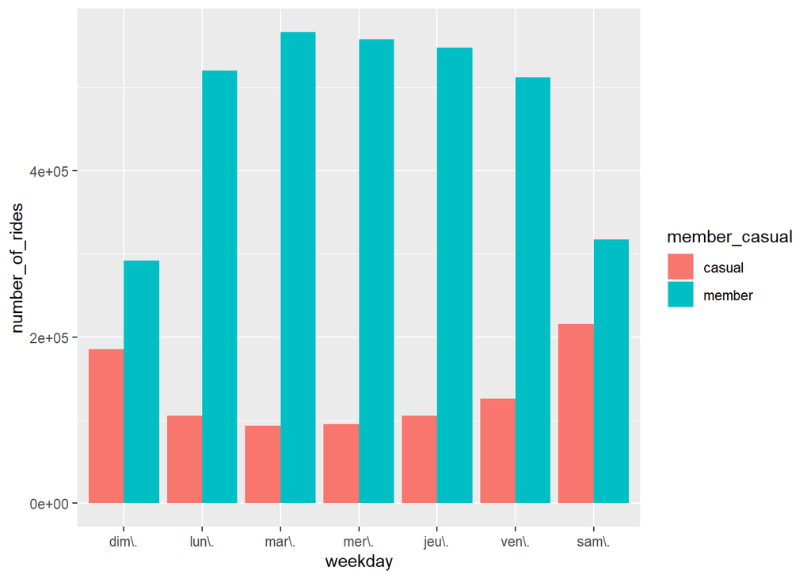

```r
# Let's visualize the number of rides by rider type
g1 <- all_trips_v2 %>%
  mutate(weekday = wday(started_at, label = TRUE)) %>%
  group_by(member_casual, weekday) %>%
  summarise(number_of_rides = n()
            ,average_duration = mean(ride_length)) %>%
  arrange(member_casual, weekday)  %>%
  ggplot(aes(x = weekday, y = number_of_rides, fill = member_casual)) +
  geom_col(position = "dodge")
ggsave("wday_nrides.png", plot = g1)
g1
```

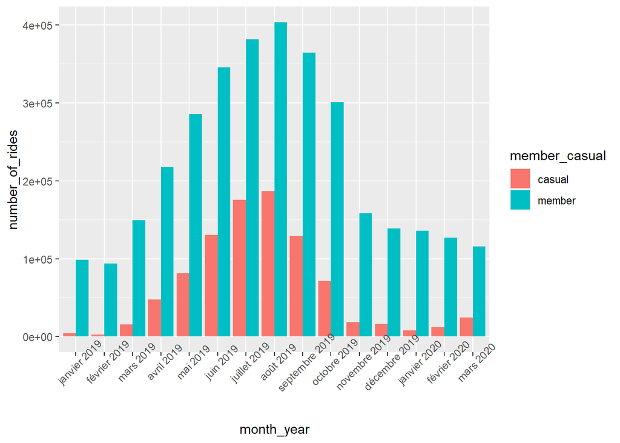

```r
#More Vizualisations for number of rides member vs Casual
#Evolution mensuelle du nombres de déplacements à vélos
#Extraire de la variable month_year, le mois
all_trips_v2 <- all_trips_v2 %>%
  mutate(month_year = paste(month, year, sep=" "))

all_trips_v2$month_year <- factor(all_trips_v2$month_year,
         level = c("janvier 2019", "février 2019", "mars 2019", "avril 2019", "mai 2019", "juin 2019", "juillet 2019", "août 2019", "septembre 2019", "octobre 2019", "novembre 2019", "décembre 2019", "janvier 2020", "février 2020", "mars 2020"), ordered = TRUE)

 g2 <- all_trips_v2 %>%
    group_by(member_casual, month_year ) %>%
  summarise(number_of_rides = n()
            ,average_duration = mean(ride_length)) %>%
  ggplot(aes(x = month_year, y = number_of_rides, fill = member_casual))+
           geom_col(position = "dodge")+
             theme(axis.text.x = element_text(angle=45))
 ggsave("month_ridelegth.png", plot = g2)
 g2
```

```r
#Evolutions saisonnières des déplacements hebdomadaires à vélos
#création de la variable Saison
all_trips_v2$season <- ifelse(all_trips_v2$month_year %in% c("janvier 2019", "février 2019"), "hiver 2019",
                              ifelse(all_trips_v2$month_year %in% c("mars 2019", "avril 2019", "mai 2019"), "printemps 2019",
                                     ifelse(all_trips_v2$month_year %in% c("juin 2019", "juillet 2019", "août 2019"), "été 2019",
                                            ifelse(all_trips_v2$month_year %in% c("septembre 2019", "octobre 2019", "novembre 2019"), "automne 2019",
                                                   ifelse(all_trips_v2$month_year %in% c("décembre 2019", "janvier 2020", "février 2020"), "hiver 2020", "D printemps 2020")))))
nrow(is.na(all_trips_v2$season)) #pas de valeur nulle
```

[output not shown]

```r
str(all_trips_v2$season)
```

```
##  chr [1:4241124] "hiver 2019" "hiver 2019" "hiver 2019" "hiver 2019" ...
```

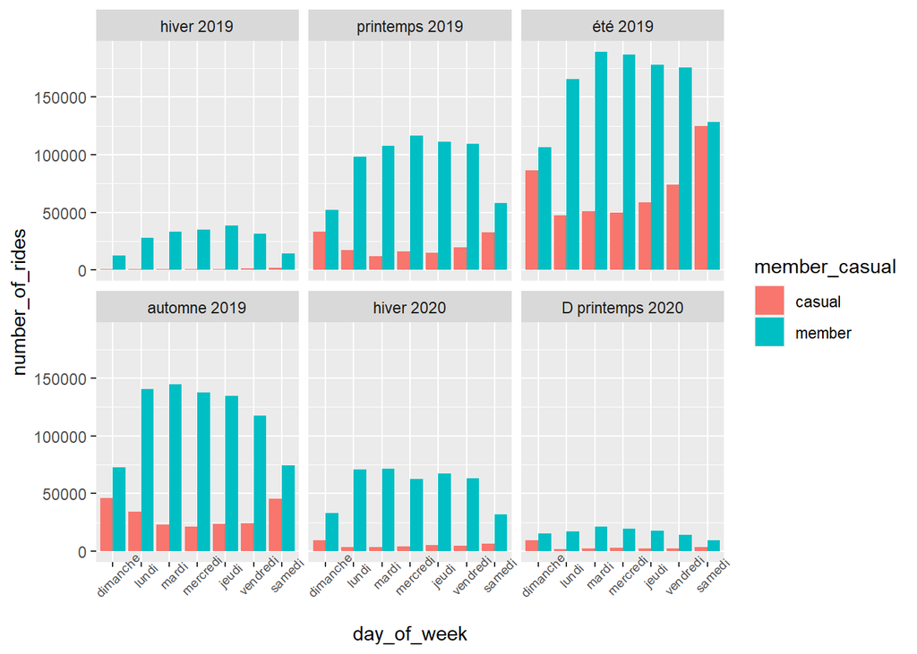

```r
  all_trips_v2$season <- factor(all_trips_v2$season,
                                level = c("hiver 2019", "printemps 2019", "été 2019", "automne 2019", "hiver 2020", "D printemps 2020"), ordered = TRUE)

#Visualisation déplacements à vélos hebodmadaires par saison
g3 <- all_trips_v2 %>%
  group_by(member_casual, season, day_of_week) %>%
  summarise(number_of_rides = n()) %>%
  ggplot(aes(x=day_of_week, y=number_of_rides, fill = member_casual))+
  geom_col(position = "dodge")+
  theme(axis.text.x = element_text(angle = 45, size = 7))+
   facet_wrap(~season)
ggsave("season_nride.png", plot = g3)
g3
```

Les saisons : - Hiver : Décembre, janvier, février - Printemps : Mars, avril, Mai - Eté : Juin, Juillet, Aout - Automne : Septembre, Octobre, Novembre

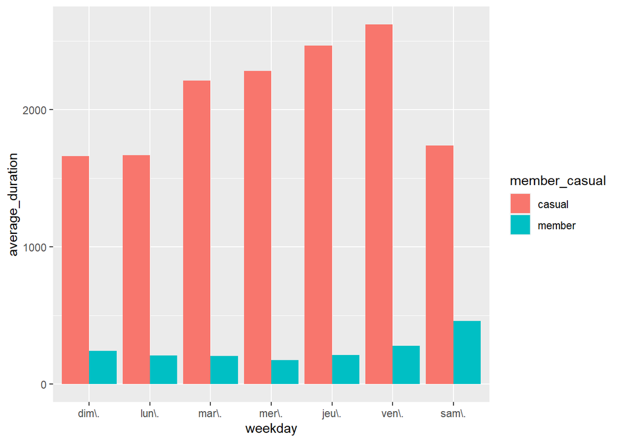

```r
# Let's create a visualization for average duration
g4 <- all_trips_v2 %>%
  mutate(weekday = wday(started_at, label = TRUE)) %>%
  group_by(member_casual, weekday) %>%
  summarise(number_of_rides = n()
            ,average_duration = mean(ride_length)) %>%
  arrange(member_casual, weekday)  %>%
  ggplot(aes(x = weekday, y = average_duration, fill = member_casual)) +
  geom_col(position = "dodge")
g4
```

```r
ggsave("wday_duration.png", plot = g4)
```

```r
#Vizualisation for average duration per season


g5 <- all_trips_v2 %>%
  mutate(weekday = wday(started_at, label = TRUE)) %>%
  group_by(member_casual, season, weekday) %>%
  summarise(average_duration = mean(ride_length)) %>%
   ggplot(aes(x = weekday, y = average_duration, fill = member_casual)) +
  geom_col(position = "dodge")+
  theme(axis.text.x = element_text(angle = 45, size = 7))
  facet_wrap(~season)
```

[output not shown]

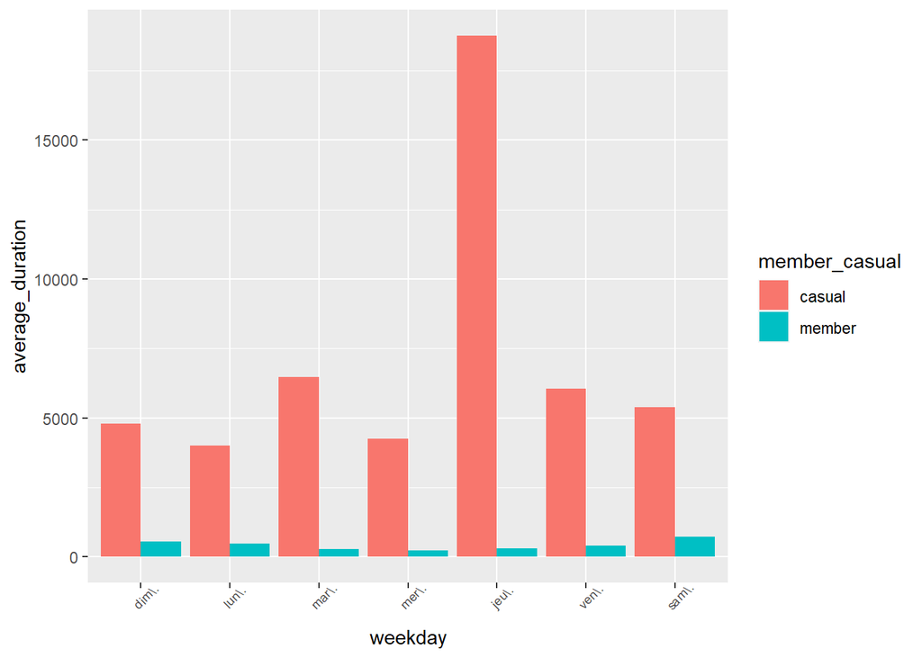

```r
g5
```

```r
ggsave("season_duration.png", plot = g5)
```